# Homework3

Ezgi ORAL

28 12 2020

## Reading the Data:

```r
hw3ConsData<-read_csv("GercekZamanliTuketim-01012016-01122020.csv")
```

## PART A

Naïve approaches to predict next day’s consumption:

```r
indexPartA<-which(hw3ConsData$Tarih=="01.11.2020") # Start Data
temp_lag168<-hw3ConsData[(indexPartA[1] - 168):(nrow(hw3ConsData)-168),]
dataForPartA_lag168 <- cbind(hw3ConsData[(indexPartA[1]):(nrow(hw3ConsData)),],temp_lag168)
head(dataForPartA_lag168)
```

```
##        Tarih     Saat T<fc>ketim Miktar<fd> (MWh)      Tarih     Saat
## 1 01.11.2020 00:00:00                    28.70162 25.10.2020 00:00:00
## 2 01.11.2020 01:00:00                    27.25415 25.10.2020 01:00:00
## 3 01.11.2020 02:00:00                    26.07857 25.10.2020 02:00:00
## 4 01.11.2020 03:00:00                    25.44947 25.10.2020 03:00:00
## 5 01.11.2020 04:00:00                    25.32401 25.10.2020 04:00:00
## 6 01.11.2020 05:00:00                    25.17511 25.10.2020 05:00:00
##   T<fc>ketim Miktar<fd> (MWh)
## 1                    29.48133
## 2                    28.00228
## 3                    27.11539
## 4                    26.41511
## 5                    26.07507
## 6                    26.19639
```

```r
temp_lag48<-hw3ConsData[(indexPartA[1] - 48):(nrow(hw3ConsData)-48),]
dataForPartA_lag48 <- cbind(hw3ConsData[(indexPartA[1]):(nrow(hw3ConsData)),],temp_lag48)
head(dataForPartA_lag48)
```

```
##        Tarih     Saat T<fc>ketim Miktar<fd> (MWh)      Tarih     Saat
## 1 01.11.2020 00:00:00                    28.70162 30.10.2020 00:00:00
## 2 01.11.2020 01:00:00                    27.25415 30.10.2020 01:00:00
## 3 01.11.2020 02:00:00                    26.07857 30.10.2020 02:00:00
## 4 01.11.2020 03:00:00                    25.44947 30.10.2020 03:00:00
## 5 01.11.2020 04:00:00                    25.32401 30.10.2020 04:00:00
## 6 01.11.2020 05:00:00                    25.17511 30.10.2020 05:00:00
##   T<fc>ketim Miktar<fd> (MWh)
## 1                    29.06651
## 2                    27.83889
## 3                    26.94011
## 4                    26.26080
## 5                    26.09796
## 6                    26.31940
```

Since we have calculated the predictions, now we can compare these values with the real consumption values.

```r
mape_lag168 <- mape(as.numeric(dataForPartA_lag168[,6]) , dataForPartA_lag168[,3])
summary(mape_lag168)
```

```
##    Min. 1st Qu.  Median    Mean 3rd Qu.    Max.
##   3.449   3.449   3.449   3.449   3.449   3.449
```

```r
mape_lag48 <- mape(dataForPartA_lag48[,6] , dataForPartA_lag48[,3])
summary(mape_lag48)
```

```
##    Min. 1st Qu.  Median    Mean 3rd Qu.    Max.
##    8.06    8.06    8.06    8.06    8.06    8.06
```

We see that lag_168 has a “Mape” value of 3.449% and lag_48 has a “Mape” value of 8.06%. This means that the prediction made by using lag_168 is better than lag_48. This makes sense because intuitively we would expect the same result. For example when we compare Sunday’s “routine” with Friday’s “routine” and last Sunday’s “routine”, we expect more resemblance in last Sunday’s “routine”.

When we look at both predictions, we can say that they are good predictions because their Mape values are under 10%.

## PART B

Now, we apply the linear regression model. Due to daylight savings program applied on 27.03.2016, some data are missing. Therefore we discard the day from the training data.

```r
startB<-cbind(dataForPartA_lag48,dataForPartA_lag168[,6])
startB<-startB[,c(3,6,7)]
colnames(startB)<-c("A", "B","C")

dataForPartB <- cbind(hw3ConsData[169:(indexPartA[1]-1),],hw3ConsData[121:(indexPartA[1]-49),],hw3ConsData[1:(indexPartA[1]-169),])

dataForPartB<-dataForPartB[-which(dataForPartB[,1]=="27.03.2016"),]
dataForPartB<-dataForPartB[-which(dataForPartB[,4]=="27.03.2016"),]
dataForPartB<-dataForPartB[-which(dataForPartB[,7]=="27.03.2016"),]

dataForPartB<-dataForPartB[,c(1,2,3,6,9)]

colnames(dataForPartB)<-c("Date", "Hour", "Data Real", "Data lag_48","Data lag_168")
```

Long format:

```r
head(dataForPartB)
```

```
##         Date     Hour Data Real Data lag_48 Data lag_168
## 1 08.01.2016 00:00:00  28.60202    29.18927     26.27724
## 2 08.01.2016 01:00:00  27.11237    27.61402     24.99182
## 3 08.01.2016 02:00:00  25.97534    26.57897     23.53261
## 4 08.01.2016 03:00:00  25.31555    25.71919     22.46478
## 5 08.01.2016 04:00:00  25.12815    25.86463     22.00291
## 6 08.01.2016 05:00:00  25.35622    25.91859     21.95708
```

```r
linearFit_bothLagsPartB <- lm(`Data Real`~.,data=dataForPartB[,c(3,4,5)])
summary(linearFit_bothLagsPartB)
```

```
##
## Call:
## lm(formula = `Data Real` ~ ., data = dataForPartB[, c(3, 4, 5)])
##
## Residuals:
##      Min       1Q   Median       3Q      Max
## -17.1257  -0.9843  -0.0012   1.0157  16.0974
##
## Coefficients:
##                Estimate Std. Error t value Pr(>|t|)
## (Intercept)    1.570185   0.083509   18.80   <2e-16 ***
## `Data lag_48`  0.309055   0.003096   99.82   <2e-16 ***
## `Data lag_168` 0.643032   0.003094  207.83   <2e-16 ***
## ---
## Signif. codes:  0 '***' 0.001 '**' 0.01 '*' 0.05 '.' 0.1 ' ' 1
##
## Residual standard error: 2.388 on 42141 degrees of freedom
## Multiple R-squared:  0.7757, Adjusted R-squared:  0.7757
## F-statistic: 7.288e+04 on 2 and 42141 DF,  p-value: < 2.2e-16
```

```r
testB<- as.data.frame(cbind(startB$B,startB$C))
colnames(testB)<-c("Data lag_48","Data lag_168")
estimatePartB<-(predict(linearFit_bothLagsPartB, newdata = testB))

b<-data.frame(dataForPartA_lag168[,3])

ww<-cbind(estimatePartB,b)
mapePartB<- mape(ww[,1],ww[,2])
summary(mapePartB)
```

```
##    Min. 1st Qu.  Median    Mean 3rd Qu.    Max.
##   4.231   4.231   4.231   4.231   4.231   4.231
```

We can observe all the necessary coefficients for the linear regression model that we obtained. Both lag_48 and lag_168 features are used and the intercept is also included.

When we look at the “Mape” result, it is 4.231%. We observe that this prediction model is good because it is under 10%. When we compare this result with Part A, we see that the linear regression model is better than lag_48 naive approach however, lag_168 naive approach is better than the linear regression model.

## PART C

Now, we take the hourly seasonality into account. So, we model each hour separately as follows:

```r
elements <- matrix(0,(nrow(dataForPartB)/24),24)

for (i in 1:24)
{
  elements[,i]<-which((as.numeric(dataForPartB$Hour)/3600)==(i-1))
}
combinedDataForPartC_0h<-dataForPartB[elements[,1],] #
linearFit_bothLags_0h <- lm(`Data Real`~.,data=combinedDataForPartC_0h[,c(3,4,5)])
summary(linearFit_bothLags_0h)
```

```
##
## Call:
## lm(formula = `Data Real` ~ ., data = combinedDataForPartC_0h[,
##     c(3, 4, 5)])
##
## Residuals:
##     Min      1Q  Median      3Q     Max
## -9.1642 -0.7984  0.0426  0.8819  6.4050
##
## Coefficients:
##                Estimate Std. Error t value Pr(>|t|)
## (Intercept)     2.19077    0.43225   5.068 4.44e-07 ***
## `Data lag_48`   0.48712    0.01687  28.882  < 2e-16 ***
## `Data lag_168`  0.44262    0.01683  26.293  < 2e-16 ***
## ---
## Signif. codes:  0 '***' 0.001 '**' 0.01 '*' 0.05 '.' 0.1 ' ' 1
##
## Residual standard error: 1.592 on 1753 degrees of freedom
## Multiple R-squared:  0.7206, Adjusted R-squared:  0.7203
## F-statistic:  2260 on 2 and 1753 DF,  p-value: < 2.2e-16
```

```r
test_0h<-dataForPartB[seq(1,nrow(dataForPartB)-23, by = 24),c(4,5)]
estimatePartc_0h<-(predict(linearFit_bothLags_0h, newdata = test_0h))

tempC_0h <- as.data.frame(cbind(estimatePartc_0h,combinedDataForPartC_0h[,3]))
mapePartC_0h <- mape(tempC_0h[,1],tempC_0h[,2])
summary(mapePartC_0h)
```

```
##    Min. 1st Qu.  Median    Mean 3rd Qu.    Max.
##   3.669   3.669   3.669   3.669   3.669   3.669
```

```r
combinedDataForPartC_1h<-dataForPartB[elements[,2],]
linearFit_bothLags_1h <- lm(`Data Real`~.,data=combinedDataForPartC_1h[,c(3,4,5)])
summary(linearFit_bothLags_1h)
```

```
##
## Call:
## lm(formula = `Data Real` ~ ., data = combinedDataForPartC_1h[,
##     c(3, 4, 5)])
##
## Residuals:
##     Min      1Q  Median      3Q     Max
## -9.3874 -0.7746  0.0773  0.8315  6.4522
##
## Coefficients:
##                Estimate Std. Error t value Pr(>|t|)
## (Intercept)     2.12180    0.41385   5.127 3.27e-07 ***
## `Data lag_48`   0.49214    0.01688  29.155  < 2e-16 ***
## `Data lag_168`  0.43620    0.01685  25.894  < 2e-16 ***
## ---
## Signif. codes:  0 '***' 0.001 '**' 0.01 '*' 0.05 '.' 0.1 ' ' 1
##
## Residual standard error: 1.562 on 1753 degrees of freedom
## Multiple R-squared:  0.7166, Adjusted R-squared:  0.7163
## F-statistic:  2216 on 2 and 1753 DF,  p-value: < 2.2e-16
```

```r
test_1h<- dataForPartB[seq(2,nrow(dataForPartB)-22, by = 24),]
estimatePartc_1h<-(predict(linearFit_bothLags_1h, newdata = test_1h))
tempC_1h <- as.data.frame(cbind(estimatePartc_1h,combinedDataForPartC_1h[,3]))
mapePartC_1h <- mape(tempC_1h[,1],tempC_1h[,2])
summary(mapePartC_1h)
```

```
##    Min. 1st Qu.  Median    Mean 3rd Qu.    Max.
##   3.782   3.782   3.782   3.782   3.782   3.782
```

```r
combinedDataForPartC_2h<-dataForPartB[elements[,3],]
linearFit_bothLags_2h <- lm(`Data Real`~.,data=combinedDataForPartC_2h[,c(3,4,5)])
summary(linearFit_bothLags_2h)
```

```
##
## Call:
## lm(formula = `Data Real` ~ ., data = combinedDataForPartC_2h[,
##     c(3, 4, 5)])
##
## Residuals:
##     Min      1Q  Median      3Q     Max
## -9.1588 -0.8080  0.0666  0.8594  6.2776
##
## Coefficients:
##                Estimate Std. Error t value Pr(>|t|)
## (Intercept)     2.20022    0.41074   5.357  9.6e-08 ***
## `Data lag_48`   0.49721    0.01700  29.255  < 2e-16 ***
## `Data lag_168`  0.42560    0.01696  25.100  < 2e-16 ***
## ---
## Signif. codes:  0 '***' 0.001 '**' 0.01 '*' 0.05 '.' 0.1 ' ' 1
##
## Residual standard error: 1.547 on 1753 degrees of freedom
## Multiple R-squared:  0.7016, Adjusted R-squared:  0.7013
## F-statistic:  2061 on 2 and 1753 DF,  p-value: < 2.2e-16
```

```r
test_2h<- dataForPartB[seq(3,nrow(dataForPartB)-21, by = 24),]
estimatePartc_2h<-(predict(linearFit_bothLags_2h, newdata = test_2h))
tempC_2h <- as.data.frame(cbind(estimatePartc_2h,combinedDataForPartC_2h[,3]))
mapePartC_2h <- mape(tempC_2h[,1],tempC_2h[,2])
summary(mapePartC_2h)
```

```
##    Min. 1st Qu.  Median    Mean 3rd Qu.    Max.
##   3.901   3.901   3.901   3.901   3.901   3.901
```

```r
combinedDataForPartC_3h<-dataForPartB[elements[,4],]
linearFit_bothLags_3h <- lm(`Data Real`~.,data=combinedDataForPartC_3h[,c(3,4,5)])
summary(linearFit_bothLags_3h)
```

```
##
## Call:
## lm(formula = `Data Real` ~ ., data = combinedDataForPartC_3h[,
##     c(3, 4, 5)])
##
## Residuals:
##     Min      1Q  Median      3Q     Max
## -8.8700 -0.8164  0.0664  0.8713  6.2696
##
## Coefficients:
##                Estimate Std. Error t value Pr(>|t|)
## (Intercept)     2.23371    0.40832    5.47 5.14e-08 ***
## `Data lag_48`   0.49285    0.01705   28.91  < 2e-16 ***
## `Data lag_168`  0.42673    0.01701   25.09  < 2e-16 ***
## ---
## Signif. codes:  0 '***' 0.001 '**' 0.01 '*' 0.05 '.' 0.1 ' ' 1
##
## Residual standard error: 1.522 on 1753 degrees of freedom
## Multiple R-squared:  0.6916, Adjusted R-squared:  0.6913
## F-statistic:  1966 on 2 and 1753 DF,  p-value: < 2.2e-16
```

```r
test_3h<- dataForPartB[seq(4,nrow(dataForPartB)-20, by = 24),]
estimatePartc_3h<-(predict(linearFit_bothLags_3h, newdata = test_3h))
tempC_3h <- as.data.frame(cbind(estimatePartc_3h,combinedDataForPartC_3h[,3]))
mapePartC_3h <- mape(tempC_3h[,1],tempC_3h[,2])
summary(mapePartC_3h)
```

```
##    Min. 1st Qu.  Median    Mean 3rd Qu.    Max.
##   3.962   3.962   3.962   3.962   3.962   3.962
```

```r
combinedDataForPartC_4h<-dataForPartB[elements[,5],]
linearFit_bothLags_4h <- lm(`Data Real`~.,data=combinedDataForPartC_4h[,c(3,4,5)])
summary(linearFit_bothLags_4h)
```

```
##
## Call:
## lm(formula = `Data Real` ~ ., data = combinedDataForPartC_4h[,
##     c(3, 4, 5)])
##
## Residuals:
##     Min      1Q  Median      3Q     Max
## -7.8871 -0.8041  0.0395  0.8633  6.2855
##
## Coefficients:
##                Estimate Std. Error t value Pr(>|t|)
## (Intercept)     2.21111    0.41050   5.386 8.16e-08 ***
## `Data lag_48`   0.47472    0.01697  27.969  < 2e-16 ***
## `Data lag_168`  0.44471    0.01693  26.267  < 2e-16 ***
## ---
## Signif. codes:  0 '***' 0.001 '**' 0.01 '*' 0.05 '.' 0.1 ' ' 1
##
## Residual standard error: 1.496 on 1753 degrees of freedom
## Multiple R-squared:  0.6838, Adjusted R-squared:  0.6834
## F-statistic:  1895 on 2 and 1753 DF,  p-value: < 2.2e-16
```

```r
test_4h<- dataForPartB[seq(5,nrow(dataForPartB)-19, by = 24),]
estimatePartc_4h<-(predict(linearFit_bothLags_4h, newdata = test_4h))
tempC_4h <- as.data.frame(cbind(estimatePartc_4h,combinedDataForPartC_4h[,3]))
mapePartC_4h <- mape(tempC_4h[,1],tempC_4h[,2])
summary(mapePartC_4h)
```

```
##    Min. 1st Qu.  Median    Mean 3rd Qu.    Max.
##   3.952   3.952   3.952   3.952   3.952   3.952
```

```r
combinedDataForPartC_5h<-dataForPartB[elements[,6],]
linearFit_bothLags_5h <- lm(`Data Real`~.,data=combinedDataForPartC_5h[,c(3,4,5)])
summary(linearFit_bothLags_5h)
```

```
##
## Call:
## lm(formula = `Data Real` ~ ., data = combinedDataForPartC_5h[,
##     c(3, 4, 5)])
##
## Residuals:
##     Min      1Q  Median      3Q     Max
## -7.4369 -0.7794  0.0346  0.8392  6.3753
##
## Coefficients:
##                Estimate Std. Error t value Pr(>|t|)
## (Intercept)     2.22974    0.41978   5.312 1.22e-07 ***
## `Data lag_48`   0.44028    0.01690  26.054  < 2e-16 ***
## `Data lag_168`  0.47787    0.01686  28.335  < 2e-16 ***
## ---
## Signif. codes:  0 '***' 0.001 '**' 0.01 '*' 0.05 '.' 0.1 ' ' 1
##
## Residual standard error: 1.486 on 1753 degrees of freedom
## Multiple R-squared:  0.6702, Adjusted R-squared:  0.6698
## F-statistic:  1781 on 2 and 1753 DF,  p-value: < 2.2e-16
```

```r
test_5h<- dataForPartB[seq(6,nrow(dataForPartB)-18, by = 24),]
estimatePartc_5h<-(predict(linearFit_bothLags_5h, newdata = test_5h))
tempC_5h <- as.data.frame(cbind(estimatePartc_5h,combinedDataForPartC_5h[,3]))
mapePartC_5h <- mape(tempC_5h[,1],tempC_5h[,2])
summary(mapePartC_5h)
```

```
##    Min. 1st Qu.  Median    Mean 3rd Qu.    Max.
##   3.981   3.981   3.981   3.981   3.981   3.981
```

```r
combinedDataForPartC_6h<-dataForPartB[elements[,7],]
linearFit_bothLags_6h <- lm(`Data Real`~.,data=combinedDataForPartC_6h[,c(3,4,5)])
summary(linearFit_bothLags_6h)
```

```
##
## Call:
## lm(formula = `Data Real` ~ ., data = combinedDataForPartC_6h[,
##     c(3, 4, 5)])
##
## Residuals:
##     Min      1Q  Median      3Q     Max
## -7.4209 -0.7292  0.0377  0.8514  7.0409
##
## Coefficients:
##                Estimate Std. Error t value Pr(>|t|)
## (Intercept)     2.13105    0.42518   5.012 5.93e-07 ***
## `Data lag_48`   0.37687    0.01652  22.817  < 2e-16 ***
## `Data lag_168`  0.54516    0.01650  33.041  < 2e-16 ***
## ---
## Signif. codes:  0 '***' 0.001 '**' 0.01 '*' 0.05 '.' 0.1 ' ' 1
##
## Residual standard error: 1.565 on 1753 degrees of freedom
## Multiple R-squared:  0.6701, Adjusted R-squared:  0.6697
## F-statistic:  1780 on 2 and 1753 DF,  p-value: < 2.2e-16
```

```r
test_6h<- dataForPartB[seq(7,nrow(dataForPartB)-17, by = 24),]
estimatePartc_6h<-(predict(linearFit_bothLags_6h, newdata = test_6h))
tempC_6h <- as.data.frame(cbind(estimatePartc_6h,combinedDataForPartC_6h[,3]))
mapePartC_6h <- mape(tempC_6h[,1],tempC_6h[,2])
summary(mapePartC_6h)
```

```
##    Min. 1st Qu.  Median    Mean 3rd Qu.    Max.
##   4.187   4.187   4.187   4.187   4.187   4.187
```

```r
combinedDataForPartC_7h<-dataForPartB[elements[,8],]
linearFit_bothLags_7h <- lm(`Data Real`~.,data=combinedDataForPartC_7h[,c(3,4,5)])
summary(linearFit_bothLags_7h)
```

```
##
## Call:
## lm(formula = `Data Real` ~ ., data = combinedDataForPartC_7h[,
##     c(3, 4, 5)])
##
## Residuals:
##     Min      1Q  Median      3Q     Max
## -8.8113 -0.8054  0.0649  0.9311  8.9517
##
## Coefficients:
##                Estimate Std. Error t value Pr(>|t|)
## (Intercept)     2.32858    0.47340   4.919 9.52e-07 ***
## `Data lag_48`   0.26736    0.01570  17.030  < 2e-16 ***
## `Data lag_168`  0.65120    0.01568  41.528  < 2e-16 ***
## ---
## Signif. codes:  0 '***' 0.001 '**' 0.01 '*' 0.05 '.' 0.1 ' ' 1
##
## Residual standard error: 1.914 on 1753 degrees of freedom
## Multiple R-squared:  0.6534, Adjusted R-squared:  0.653
## F-statistic:  1653 on 2 and 1753 DF,  p-value: < 2.2e-16
```

```r
test_7h<- dataForPartB[seq(8,nrow(dataForPartB)-16, by = 24),]
estimatePartc_7h<-(predict(linearFit_bothLags_7h, newdata = test_7h))
tempC_7h <- as.data.frame(cbind(estimatePartc_7h,combinedDataForPartC_7h[,3]))
mapePartC_7h <- mape(tempC_7h[,1],tempC_7h[,2])
summary(mapePartC_7h)
```

```
##    Min. 1st Qu.  Median    Mean 3rd Qu.    Max.
##    4.77    4.77    4.77    4.77    4.77    4.77
```

```r
combinedDataForPartC_8h<-dataForPartB[elements[,9],]
linearFit_bothLags_8h <- lm(`Data Real`~.,data=combinedDataForPartC_8h[,c(3,4,5)])
summary(linearFit_bothLags_8h)
```

```
##
## Call:
## lm(formula = `Data Real` ~ ., data = combinedDataForPartC_8h[,
##     c(3, 4, 5)])
##
## Residuals:
##      Min       1Q   Median       3Q      Max
## -13.4349  -1.0184   0.1339   1.1836  13.0710
##
## Coefficients:
##                Estimate Std. Error t value Pr(>|t|)
## (Intercept)     3.25274    0.60621   5.366 9.14e-08 ***
## `Data lag_48`   0.17454    0.01521  11.478  < 2e-16 ***
## `Data lag_168`  0.72416    0.01520  47.649  < 2e-16 ***
## ---
## Signif. codes:  0 '***' 0.001 '**' 0.01 '*' 0.05 '.' 0.1 ' ' 1
##
## Residual standard error: 2.709 on 1753 degrees of freedom
## Multiple R-squared:  0.6166, Adjusted R-squared:  0.6161
## F-statistic:  1409 on 2 and 1753 DF,  p-value: < 2.2e-16
```

```r
test_8h<- dataForPartB[seq(9,nrow(dataForPartB)-15, by = 24),]
estimatePartc_8h<-(predict(linearFit_bothLags_8h, newdata = test_8h))
tempC_8h <- as.data.frame(cbind(estimatePartc_8h,combinedDataForPartC_8h[,3]))
mapePartC_8h <- mape(tempC_8h[,1],tempC_8h[,2])
summary(mapePartC_8h)
```

```
##    Min. 1st Qu.  Median    Mean 3rd Qu.    Max.
##   5.842   5.842   5.842   5.842   5.842   5.842
```

```r
combinedDataForPartC_9h<-dataForPartB[elements[,10],]
linearFit_bothLags_9h <- lm(`Data Real`~.,data=combinedDataForPartC_9h[,c(3,4,5)])
summary(linearFit_bothLags_9h)
```

```
##
## Call:
## lm(formula = `Data Real` ~ ., data = combinedDataForPartC_9h[,
##     c(3, 4, 5)])
##
## Residuals:
##      Min       1Q   Median       3Q      Max
## -15.6738  -1.2990   0.1213   1.3487  15.0037
##
## Coefficients:
##                Estimate Std. Error t value Pr(>|t|)
## (Intercept)     3.61443    0.65686   5.503  4.3e-08 ***
## `Data lag_48`   0.17521    0.01536  11.405  < 2e-16 ***
## `Data lag_168`  0.71931    0.01536  46.817  < 2e-16 ***
## ---
## Signif. codes:  0 '***' 0.001 '**' 0.01 '*' 0.05 '.' 0.1 ' ' 1
##
## Residual standard error: 3.06 on 1753 degrees of freedom
## Multiple R-squared:  0.6079, Adjusted R-squared:  0.6074
## F-statistic:  1359 on 2 and 1753 DF,  p-value: < 2.2e-16
```

```r
test_9h<- dataForPartB[seq(10,nrow(dataForPartB)-14, by = 24),]
estimatePartc_9h<-(predict(linearFit_bothLags_9h, newdata = test_9h))
tempC_9h <- as.data.frame(cbind(estimatePartc_9h,combinedDataForPartC_9h[,3]))
mapePartC_9h <- mape(tempC_9h[,1],tempC_9h[,2])
summary(mapePartC_9h)
```

```
##    Min. 1st Qu.  Median    Mean 3rd Qu.    Max.
##   6.258   6.258   6.258   6.258   6.258   6.258
```

```r
combinedDataForPartC_10h<-dataForPartB[elements[,11],]
linearFit_bothLags_10h <- lm(`Data Real`~.,data=combinedDataForPartC_10h[,c(3,4,5)])
summary(linearFit_bothLags_10h)
```

```
##
## Call:
## lm(formula = `Data Real` ~ ., data = combinedDataForPartC_10h[,
##     c(3, 4, 5)])
##
## Residuals:
##      Min       1Q   Median       3Q      Max
## -16.5226  -1.3597   0.0961   1.4467  15.5399
##
## Coefficients:
##                Estimate Std. Error t value Pr(>|t|)
## (Intercept)     3.76129    0.66890   5.623 2.18e-08 ***
## `Data lag_48`   0.20700    0.01586  13.055  < 2e-16 ***
## `Data lag_168`  0.68554    0.01586  43.219  < 2e-16 ***
## ---
## Signif. codes:  0 '***' 0.001 '**' 0.01 '*' 0.05 '.' 0.1 ' ' 1
##
## Residual standard error: 3.08 on 1753 degrees of freedom
## Multiple R-squared:  0.5944, Adjusted R-squared:  0.5939
## F-statistic:  1284 on 2 and 1753 DF,  p-value: < 2.2e-16
```

```r
test_10h<- dataForPartB[seq(11,nrow(dataForPartB)-13, by = 24),]
estimatePartc_10h<-(predict(linearFit_bothLags_10h, newdata = test_10h))
tempC_10h <- as.data.frame(cbind(estimatePartc_10h,combinedDataForPartC_10h[,3]))
mapePartC_10h <- mape(tempC_10h[,1],tempC_10h[,2])
summary(mapePartC_10h)
```

```
##    Min. 1st Qu.  Median    Mean 3rd Qu.    Max.
##   6.262   6.262   6.262   6.262   6.262   6.262
```

```r
combinedDataForPartC_11h<-dataForPartB[elements[,12],]
linearFit_bothLags_11h <- lm(`Data Real`~.,data=combinedDataForPartC_11h[,c(3,4,5)])
summary(linearFit_bothLags_11h)
```

```
##
## Call:
## lm(formula = `Data Real` ~ ., data = combinedDataForPartC_11h[,
##     c(3, 4, 5)])
##
## Residuals:
##      Min       1Q   Median       3Q      Max
## -17.0620  -1.4376   0.0853   1.5191  15.6704
##
## Coefficients:
##                Estimate Std. Error t value Pr(>|t|)
## (Intercept)     3.98052    0.68603   5.802 7.75e-09 ***
## `Data lag_48`   0.22565    0.01622  13.914  < 2e-16 ***
## `Data lag_168`  0.66238    0.01623  40.816  < 2e-16 ***
## ---
## Signif. codes:  0 '***' 0.001 '**' 0.01 '*' 0.05 '.' 0.1 ' ' 1
##
## Residual standard error: 3.129 on 1753 degrees of freedom
## Multiple R-squared:  0.5808, Adjusted R-squared:  0.5803
## F-statistic:  1214 on 2 and 1753 DF,  p-value: < 2.2e-16
```

```r
test_11h<- dataForPartB[seq(12,nrow(dataForPartB)-12, by = 24),]
estimatePartc_11h<-(predict(linearFit_bothLags_11h, newdata = test_11h))
tempC_11h <- as.data.frame(cbind(estimatePartc_11h,combinedDataForPartC_11h[,3]))
mapePartC_11h <- mape(tempC_11h[,1],tempC_11h[,2])
summary(mapePartC_11h)
```

```
##    Min. 1st Qu.  Median    Mean 3rd Qu.    Max.
##   6.323   6.323   6.323   6.323   6.323   6.323
```

```r
combinedDataForPartC_12h<-dataForPartB[elements[,13],]
linearFit_bothLags_12h <- lm(`Data Real`~.,data=combinedDataForPartC_12h[,c(3,4,5)])
summary(linearFit_bothLags_12h)
```

```
##
## Call:
## lm(formula = `Data Real` ~ ., data = combinedDataForPartC_12h[,
##     c(3, 4, 5)])
##
## Residuals:
##      Min       1Q   Median       3Q      Max
## -15.4733  -1.4291   0.0397   1.5150  14.5998
##
## Coefficients:
##                Estimate Std. Error t value Pr(>|t|)
## (Intercept)     3.68452    0.63300   5.821 6.95e-09 ***
## `Data lag_48`   0.28057    0.01666  16.846  < 2e-16 ***
## `Data lag_168`  0.61217    0.01667  36.728  < 2e-16 ***
## ---
## Signif. codes:  0 '***' 0.001 '**' 0.01 '*' 0.05 '.' 0.1 ' ' 1
##
## Residual standard error: 2.872 on 1753 degrees of freedom
## Multiple R-squared:  0.5905, Adjusted R-squared:  0.5901
## F-statistic:  1264 on 2 and 1753 DF,  p-value: < 2.2e-16
```

```r
test_12h<- dataForPartB[seq(13,nrow(dataForPartB)-11, by = 24),]
estimatePartc_12h<-(predict(linearFit_bothLags_12h, newdata = test_12h))
tempC_12h <- as.data.frame(cbind(estimatePartc_12h,combinedDataForPartC_12h[,3]))
mapePartC_12h <- mape(tempC_12h[,1],tempC_12h[,2])
summary(mapePartC_12h)
```

```
##    Min. 1st Qu.  Median    Mean 3rd Qu.    Max.
##   6.125   6.125   6.125   6.125   6.125   6.125
```

```r
combinedDataForPartC_13h<-dataForPartB[elements[,14],]
linearFit_bothLags_13h <- lm(`Data Real`~.,data=combinedDataForPartC_13h[,c(3,4,5)])
summary(linearFit_bothLags_13h)
```

```
##
## Call:
## lm(formula = `Data Real` ~ ., data = combinedDataForPartC_13h[,
##     c(3, 4, 5)])
##
## Residuals:
##      Min       1Q   Median       3Q      Max
## -15.5115  -1.4502  -0.0556   1.5255  14.7929
##
## Coefficients:
##                Estimate Std. Error t value Pr(>|t|)
## (Intercept)     3.83295    0.64366   5.955 3.14e-09 ***
## `Data lag_48`   0.30382    0.01693  17.948  < 2e-16 ***
## `Data lag_168`  0.58583    0.01693  34.595  < 2e-16 ***
## ---
## Signif. codes:  0 '***' 0.001 '**' 0.01 '*' 0.05 '.' 0.1 ' ' 1
##
## Residual standard error: 2.943 on 1753 degrees of freedom
## Multiple R-squared:  0.5821, Adjusted R-squared:  0.5816
## F-statistic:  1221 on 2 and 1753 DF,  p-value: < 2.2e-16
```

```r
test_13h<- dataForPartB[seq(14,nrow(dataForPartB)-10, by = 24),]
estimatePartc_13h<-(predict(linearFit_bothLags_13h, newdata = test_13h))
tempC_13h <- as.data.frame(cbind(estimatePartc_13h,combinedDataForPartC_13h[,3]))
mapePartC_13h <- mape(tempC_13h[,1],tempC_13h[,2])
summary(mapePartC_13h)
```

```
##    Min. 1st Qu.  Median    Mean 3rd Qu.    Max.
##    6.22    6.22    6.22    6.22    6.22    6.22
```

```r
combinedDataForPartC_14h<-dataForPartB[elements[,15],]
linearFit_bothLags_14h <- lm(`Data Real`~.,data=combinedDataForPartC_14h[,c(3,4,5)])
summary(linearFit_bothLags_14h)
```

```
##
## Call:
## lm(formula = `Data Real` ~ ., data = combinedDataForPartC_14h[,
##     c(3, 4, 5)])
##
## Residuals:
##      Min       1Q   Median       3Q      Max
## -16.0789  -1.5577  -0.0202   1.6524  15.5843
##
## Coefficients:
##                Estimate Std. Error t value Pr(>|t|)
## (Intercept)     4.09940    0.68578   5.978 2.74e-09 ***
## `Data lag_48`   0.25994    0.01667  15.594  < 2e-16 ***
## `Data lag_168`  0.62450    0.01668  37.448  < 2e-16 ***
## ---
## Signif. codes:  0 '***' 0.001 '**' 0.01 '*' 0.05 '.' 0.1 ' ' 1
##
## Residual standard error: 3.163 on 1753 degrees of freedom
## Multiple R-squared:  0.5678, Adjusted R-squared:  0.5673
## F-statistic:  1151 on 2 and 1753 DF,  p-value: < 2.2e-16
```

```r
test_14h<- dataForPartB[seq(15,nrow(dataForPartB)-9, by = 24),]
estimatePartc_14h<-(predict(linearFit_bothLags_14h, newdata = test_14h))
tempC_14h <- as.data.frame(cbind(estimatePartc_14h,combinedDataForPartC_14h[,3]))
mapePartC_14h <- mape(tempC_14h[,1],tempC_14h[,2])
summary(mapePartC_14h)
```

```
##    Min. 1st Qu.  Median    Mean 3rd Qu.    Max.
##   6.511   6.511   6.511   6.511   6.511   6.511
```

```r
combinedDataForPartC_15h<-dataForPartB[elements[,16],]
linearFit_bothLags_15h <- lm(`Data Real`~.,data=combinedDataForPartC_15h[,c(3,4,5)])
summary(linearFit_bothLags_15h)
```

```
##
## Call:
## lm(formula = `Data Real` ~ ., data = combinedDataForPartC_15h[,
##     c(3, 4, 5)])
##
## Residuals:
##      Min       1Q   Median       3Q      Max
## -15.8905  -1.5336   0.0299   1.5798  15.3322
##
## Coefficients:
##                Estimate Std. Error t value Pr(>|t|)
## (Intercept)     3.98394    0.67893   5.868 5.26e-09 ***
## `Data lag_48`   0.25664    0.01655  15.506  < 2e-16 ***
## `Data lag_168`  0.63083    0.01656  38.098  < 2e-16 ***
## ---
## Signif. codes:  0 '***' 0.001 '**' 0.01 '*' 0.05 '.' 0.1 ' ' 1
##
## Residual standard error: 3.122 on 1753 degrees of freedom
## Multiple R-squared:  0.5741, Adjusted R-squared:  0.5736
## F-statistic:  1181 on 2 and 1753 DF,  p-value: < 2.2e-16
```

```r
test_15h<- dataForPartB[seq(16,nrow(dataForPartB)-8, by = 24),]
estimatePartc_15h<-(predict(linearFit_bothLags_15h, newdata = test_15h))
tempC_15h <- as.data.frame(cbind(estimatePartc_15h,combinedDataForPartC_15h[,3]))
mapePartC_15h <- mape(tempC_15h[,1],tempC_15h[,2])
summary(mapePartC_15h)
```

```
##    Min. 1st Qu.  Median    Mean 3rd Qu.    Max.
##   6.438   6.438   6.438   6.438   6.438   6.438
```

```r
combinedDataForPartC_16h<-dataForPartB[elements[,17],]
linearFit_bothLags_16h <- lm(`Data Real`~.,data=combinedDataForPartC_16h[,c(3,4,5)])
summary(linearFit_bothLags_16h)
```

```
##
## Call:
## lm(formula = `Data Real` ~ ., data = combinedDataForPartC_16h[,
##     c(3, 4, 5)])
##
## Residuals:
##      Min       1Q   Median       3Q      Max
## -15.3232  -1.4685   0.0396   1.5126  15.0151
##
## Coefficients:
##                Estimate Std. Error t value Pr(>|t|)
## (Intercept)     3.85318    0.67467   5.711 1.31e-08 ***
## `Data lag_48`   0.24733    0.01633  15.145  < 2e-16 ***
## `Data lag_168`  0.64443    0.01634  39.443  < 2e-16 ***
## ---
## Signif. codes:  0 '***' 0.001 '**' 0.01 '*' 0.05 '.' 0.1 ' ' 1
##
## Residual standard error: 3.034 on 1753 degrees of freedom
## Multiple R-squared:  0.5845, Adjusted R-squared:  0.584
## F-statistic:  1233 on 2 and 1753 DF,  p-value: < 2.2e-16
```

```r
test_16h<- dataForPartB[seq(17,nrow(dataForPartB)-7, by = 24),]
estimatePartc_16h<-(predict(linearFit_bothLags_16h, newdata = test_16h))
tempC_16h <- as.data.frame(cbind(estimatePartc_16h,combinedDataForPartC_16h[,3]))
mapePartC_16h <- mape(tempC_16h[,1],tempC_16h[,2])
summary(mapePartC_16h)
```

```
##    Min. 1st Qu.  Median    Mean 3rd Qu.    Max.
##   6.177   6.177   6.177   6.177   6.177   6.177
```

```r
combinedDataForPartC_17h<-dataForPartB[elements[,18],]
linearFit_bothLags_17h <- lm(`Data Real`~.,data=combinedDataForPartC_17h[,c(3,4,5)])
summary(linearFit_bothLags_17h)
```

```
##
## Call:
## lm(formula = `Data Real` ~ ., data = combinedDataForPartC_17h[,
##     c(3, 4, 5)])
##
## Residuals:
##      Min       1Q   Median       3Q      Max
## -14.1292  -1.3297   0.0326   1.3736  13.2970
##
## Coefficients:
##                Estimate Std. Error t value Pr(>|t|)
## (Intercept)     3.43918    0.63960   5.377 8.59e-08 ***
## `Data lag_48`   0.26214    0.01612  16.264  < 2e-16 ***
## `Data lag_168`  0.64174    0.01612  39.802  < 2e-16 ***
## ---
## Signif. codes:  0 '***' 0.001 '**' 0.01 '*' 0.05 '.' 0.1 ' ' 1
##
## Residual standard error: 2.758 on 1753 degrees of freedom
## Multiple R-squared:  0.6137, Adjusted R-squared:  0.6132
## F-statistic:  1392 on 2 and 1753 DF,  p-value: < 2.2e-16
```

```r
test_17h<- dataForPartB[seq(18,nrow(dataForPartB)-6, by = 24),]
estimatePartc_17h<-(predict(linearFit_bothLags_17h, newdata = test_17h))
tempC_17h <- as.data.frame(cbind(estimatePartc_17h,combinedDataForPartC_17h[,3]))
mapePartC_17h <- mape(tempC_17h[,1],tempC_17h[,2])
summary(mapePartC_17h)
```

```
##    Min. 1st Qu.  Median    Mean 3rd Qu.    Max.
##   5.574   5.574   5.574   5.574   5.574   5.574
```

```r
combinedDataForPartC_18h<-dataForPartB[elements[,19],]
linearFit_bothLags_18h <- lm(`Data Real`~.,data=combinedDataForPartC_18h[,c(3,4,5)])
summary(linearFit_bothLags_18h)
```

```
##
## Call:
## lm(formula = `Data Real` ~ ., data = combinedDataForPartC_18h[,
##     c(3, 4, 5)])
##
## Residuals:
##      Min       1Q   Median       3Q      Max
## -12.6915  -1.1073   0.0685   1.2060  10.5129
##
## Coefficients:
##                Estimate Std. Error t value Pr(>|t|)
## (Intercept)     3.08340    0.58488   5.272 1.52e-07 ***
## `Data lag_48`   0.33359    0.01646  20.263  < 2e-16 ***
## `Data lag_168`  0.58039    0.01646  35.260  < 2e-16 ***
## ---
## Signif. codes:  0 '***' 0.001 '**' 0.01 '*' 0.05 '.' 0.1 ' ' 1
##
## Residual standard error: 2.31 on 1753 degrees of freedom
## Multiple R-squared:  0.6479, Adjusted R-squared:  0.6475
## F-statistic:  1613 on 2 and 1753 DF,  p-value: < 2.2e-16
```

```r
test_18h<- dataForPartB[seq(19,nrow(dataForPartB)-5, by = 24),]
estimatePartc_18h<-(predict(linearFit_bothLags_18h, newdata = test_18h))
tempC_18h <- as.data.frame(cbind(estimatePartc_18h,combinedDataForPartC_18h[,3]))
mapePartC_18h <- mape(tempC_18h[,1],tempC_18h[,2])
summary(mapePartC_18h)
```

```
##    Min. 1st Qu.  Median    Mean 3rd Qu.    Max.
##   4.687   4.687   4.687   4.687   4.687   4.687
```

```r
combinedDataForPartC_19h<-dataForPartB[elements[,20],]
linearFit_bothLags_19h <- lm(`Data Real`~.,data=combinedDataForPartC_19h[,c(3,4,5)])
summary(linearFit_bothLags_19h)
```

```
##
## Call:
## lm(formula = `Data Real` ~ ., data = combinedDataForPartC_19h[,
##     c(3, 4, 5)])
##
## Residuals:
##      Min       1Q   Median       3Q      Max
## -11.6658  -1.0164   0.0528   1.0758   9.1665
##
## Coefficients:
##                Estimate Std. Error t value Pr(>|t|)
## (Intercept)     3.20043    0.58205   5.499 4.39e-08 ***
## `Data lag_48`   0.38693    0.01690  22.899  < 2e-16 ***
## `Data lag_168`  0.52404    0.01689  31.031  < 2e-16 ***
## ---
## Signif. codes:  0 '***' 0.001 '**' 0.01 '*' 0.05 '.' 0.1 ' ' 1
##
## Residual standard error: 2.058 on 1753 degrees of freedom
## Multiple R-squared:  0.6459, Adjusted R-squared:  0.6455
## F-statistic:  1599 on 2 and 1753 DF,  p-value: < 2.2e-16
```

```r
test_19h<- dataForPartB[seq(20,nrow(dataForPartB)-4, by = 24),]
estimatePartc_19h<-(predict(linearFit_bothLags_19h, newdata = test_19h))
tempC_19h <- as.data.frame(cbind(estimatePartc_19h,combinedDataForPartC_19h[,3]))
mapePartC_19h <- mape(tempC_19h[,1],tempC_19h[,2])
summary(mapePartC_19h)
```

```
##    Min. 1st Qu.  Median    Mean 3rd Qu.    Max.
##   4.142   4.142   4.142   4.142   4.142   4.142
```

```r
combinedDataForPartC_20h<-dataForPartB[elements[,21],]
linearFit_bothLags_20h <- lm(`Data Real`~.,data=combinedDataForPartC_20h[,c(3,4,5)])
summary(linearFit_bothLags_20h)
```

```
##
## Call:
## lm(formula = `Data Real` ~ ., data = combinedDataForPartC_20h[,
##     c(3, 4, 5)])
##
## Residuals:
##      Min       1Q   Median       3Q      Max
## -10.4014  -0.9912   0.0377   1.0446   8.4059
##
## Coefficients:
##                Estimate Std. Error t value Pr(>|t|)
## (Intercept)     2.79211    0.54019   5.169 2.63e-07 ***
## `Data lag_48`   0.40829    0.01677  24.347  < 2e-16 ***
## `Data lag_168`  0.51386    0.01676  30.663  < 2e-16 ***
## ---
## Signif. codes:  0 '***' 0.001 '**' 0.01 '*' 0.05 '.' 0.1 ' ' 1
##
## Residual standard error: 1.915 on 1753 degrees of freedom
## Multiple R-squared:  0.683,  Adjusted R-squared:  0.6826
## F-statistic:  1888 on 2 and 1753 DF,  p-value: < 2.2e-16
```

```r
test_20h<- dataForPartB[seq(21,nrow(dataForPartB)-3, by = 24),]
estimatePartc_20h<-(predict(linearFit_bothLags_20h, newdata = test_20h))
tempC_20h <- as.data.frame(cbind(estimatePartc_20h,combinedDataForPartC_20h[,3]))
mapePartC_20h <- mape(tempC_20h[,1],tempC_20h[,2])
summary(mapePartC_20h)
```

```
##    Min. 1st Qu.  Median    Mean 3rd Qu.    Max.
##   3.872   3.872   3.872   3.872   3.872   3.872
```

```r
combinedDataForPartC_21h<-dataForPartB[elements[,22],]
linearFit_bothLags_21h <- lm(`Data Real`~.,data=combinedDataForPartC_21h[,c(3,4,5)])
summary(linearFit_bothLags_21h)
```

```
##
## Call:
## lm(formula = `Data Real` ~ ., data = combinedDataForPartC_21h[,
##     c(3, 4, 5)])
##
## Residuals:
##      Min       1Q   Median       3Q      Max
## -10.0050  -0.9397  -0.0005   0.9939   8.5242
##
## Coefficients:
##                Estimate Std. Error t value Pr(>|t|)
## (Intercept)     2.66436    0.51783   5.145 2.97e-07 ***
## `Data lag_48`   0.42937    0.01683  25.519  < 2e-16 ***
## `Data lag_168`  0.49498    0.01681  29.439  < 2e-16 ***
## ---
## Signif. codes:  0 '***' 0.001 '**' 0.01 '*' 0.05 '.' 0.1 ' ' 1
##
## Residual standard error: 1.852 on 1753 degrees of freedom
## Multiple R-squared:  0.694,  Adjusted R-squared:  0.6937
## F-statistic:  1988 on 2 and 1753 DF,  p-value: < 2.2e-16
```

```r
test_21h<- dataForPartB[seq(22,nrow(dataForPartB)-2, by = 24),]
estimatePartc_21h<-(predict(linearFit_bothLags_21h, newdata = test_21h))
tempC_21h <- as.data.frame(cbind(estimatePartc_21h,combinedDataForPartC_21h[,3]))
mapePartC_21h <- mape(tempC_21h[,1],tempC_21h[,2])
summary(mapePartC_21h)
```

```
##    Min. 1st Qu.  Median    Mean 3rd Qu.    Max.
##   3.791   3.791   3.791   3.791   3.791   3.791
```

```r
combinedDataForPartC_22h<-dataForPartB[elements[,23],]
linearFit_bothLags_22h <- lm(`Data Real`~.,data=combinedDataForPartC_22h[,c(3,4,5)])
summary(linearFit_bothLags_22h)
```

```
##
## Call:
## lm(formula = `Data Real` ~ ., data = combinedDataForPartC_22h[,
##     c(3, 4, 5)])
##
## Residuals:
##      Min       1Q   Median       3Q      Max
## -10.2451  -0.9101   0.0306   0.9926   8.1401
##
## Coefficients:
##                Estimate Std. Error t value Pr(>|t|)
## (Intercept)     2.83163    0.52595   5.384 8.27e-08 ***
## `Data lag_48`   0.44291    0.01703  26.009  < 2e-16 ***
## `Data lag_168`  0.47501    0.01702  27.902  < 2e-16 ***
## ---
## Signif. codes:  0 '***' 0.001 '**' 0.01 '*' 0.05 '.' 0.1 ' ' 1
##
## Residual standard error: 1.828 on 1753 degrees of freedom
## Multiple R-squared:  0.6755, Adjusted R-squared:  0.6752
## F-statistic:  1825 on 2 and 1753 DF,  p-value: < 2.2e-16
```

```r
test_22h<- dataForPartB[seq(23,nrow(dataForPartB)-1, by = 24),]
estimatePartc_22h<-(predict(linearFit_bothLags_22h, newdata = test_22h))
tempC_22h <- as.data.frame(cbind(estimatePartc_22h,combinedDataForPartC_22h[,3]))
mapePartC_22h <- mape(tempC_22h[,1],tempC_22h[,2])
summary(mapePartC_22h)
```

```
##    Min. 1st Qu.  Median    Mean 3rd Qu.    Max.
##   3.789   3.789   3.789   3.789   3.789   3.789
```

```r
combinedDataForPartC_23h<-dataForPartB[elements[,24],]
linearFit_bothLags_23h <- lm(`Data Real`~.,data=combinedDataForPartC_23h[,c(3,4,5)])
summary(linearFit_bothLags_23h)
```

```
##
## Call:
## lm(formula = `Data Real` ~ ., data = combinedDataForPartC_23h[,
##     c(3, 4, 5)])
##
## Residuals:
##     Min      1Q  Median      3Q     Max
## -9.5703 -0.8511  0.0565  0.9182  7.9131
##
## Coefficients:
##                Estimate Std. Error t value Pr(>|t|)
## (Intercept)     2.54763    0.48675   5.234 1.86e-07 ***
## `Data lag_48`   0.45134    0.01695  26.627  < 2e-16 ***
## `Data lag_168`  0.47160    0.01695  27.828  < 2e-16 ***
## ---
## Signif. codes:  0 '***' 0.001 '**' 0.01 '*' 0.05 '.' 0.1 ' ' 1
##
## Residual standard error: 1.738 on 1753 degrees of freedom
## Multiple R-squared:  0.6929, Adjusted R-squared:  0.6925
## F-statistic:  1977 on 2 and 1753 DF,  p-value: < 2.2e-16
```

```r
test_23h<- dataForPartB[seq(24,nrow(dataForPartB), by = 24),]
estimatePartc_23h<-(predict(linearFit_bothLags_23h, newdata = test_23h))
tempC_23h <- as.data.frame(cbind(estimatePartc_23h,combinedDataForPartC_23h[,3]))
mapePartC_23h <- mape(tempC_23h[,1],tempC_23h[,2])
summary(mapePartC_23h)
```

```
##    Min. 1st Qu.  Median    Mean 3rd Qu.    Max.
##   3.787   3.787   3.787   3.787   3.787   3.787
```

```r
mapePartC<-rbind(mapePartC_0h,mapePartC_1h,mapePartC_2h, mapePartC_3h,mapePartC_4h,mapePartC_5h,mapePartC_6h,mapePartC_7h,mapePartC_8h,mapePartC_9h,mapePartC_10h,mapePartC_11h,mapePartC_12h,mapePartC_13h,mapePartC_14h,mapePartC_15h,mapePartC_16h,mapePartC_17h,mapePartC_18h,mapePartC_19h,mapePartC_20h,mapePartC_21h,mapePartC_22h,mapePartC_23h)
mapePartC
```

```
##                   [,1]
## mapePartC_0h  3.669272
## mapePartC_1h  3.782349
## mapePartC_2h  3.900706
## mapePartC_3h  3.962140
## mapePartC_4h  3.952075
## mapePartC_5h  3.981253
## mapePartC_6h  4.187151
## mapePartC_7h  4.769880
## mapePartC_8h  5.841830
## mapePartC_9h  6.258383
## mapePartC_10h 6.262227
## mapePartC_11h 6.322709
## mapePartC_12h 6.124850
## mapePartC_13h 6.219853
## mapePartC_14h 6.511254
## mapePartC_15h 6.438186
## mapePartC_16h 6.176731
## mapePartC_17h 5.574072
## mapePartC_18h 4.687248
## mapePartC_19h 4.142054
## mapePartC_20h 3.872253
## mapePartC_21h 3.791434
## mapePartC_22h 3.788893
## mapePartC_23h 3.787058
```

Above, we can see the “Mape” values for each hour. These results tell us why hourly seasonality is important. For night time (20.00 - 05.00), our predictions are superior, and for working hours (09.00 - 16.00) are inferior. However, all these predictions can be accepted as a good prediction because their “Mape” values are lower than 10%.

## PART D

Now, we apply penalized model (lasso regression) for each hour:

```r
dataForPart<-as.numeric(dataForPartB$Hour)/3600

partD_0h<-dataForPartB[which(dataForPart==0),]
colnames(partD_0h)<-c("Date", "Hour", "Data Real 0h", "Data lag_48 0h","Data lag_168 0h")

partD_1h<-dataForPartB[which(dataForPart==1),]
colnames(partD_1h)<-c("Date", "Hour", "Data Real 1h", "Data lag_48 1h","Data lag_168 1h")

partD_2h<-dataForPartB[which(dataForPart==2),]
colnames(partD_2h)<-c("Date", "Hour", "Data Real 2h", "Data lag_48 2h","Data lag_168 2h")

partD_3h<-dataForPartB[which(dataForPart==3),]
colnames(partD_3h)<-c("Date", "Hour", "Data Real 3h", "Data lag_48 3h","Data lag_168 3h")

partD_4h<-dataForPartB[which(dataForPart==4),]
colnames(partD_4h)<-c("Date", "Hour", "Data Real 4h", "Data lag_48 4h","Data lag_168 4h")

partD_5h<-dataForPartB[which(dataForPart==5),]
colnames(partD_5h)<-c("Date", "Hour", "Data Real 5h", "Data lag_48 5h","Data lag_168 5h")

partD_6h<-dataForPartB[which(dataForPart==6),]
colnames(partD_6h)<-c("Date", "Hour", "Data Real 6h", "Data lag_48 6h","Data lag_168 6h")

partD_7h<-dataForPartB[which(dataForPart==7),]
colnames(partD_7h)<-c("Date", "Hour", "Data Real 7h", "Data lag_48 7h","Data lag_168 7h")

partD_8h<-dataForPartB[which(dataForPart==8),]
colnames(partD_8h)<-c("Date", "Hour", "Data Real 8h", "Data lag_48 8h","Data lag_168 8h")

partD_9h<-dataForPartB[which(dataForPart==9),]
colnames(partD_9h)<-c("Date", "Hour", "Data Real 9h", "Data lag_48 9h","Data lag_168 9h")

partD_10h<-dataForPartB[which(dataForPart==10),]
colnames(partD_10h)<-c("Date", "Hour", "Data Real 10h", "Data lag_48 10h","Data lag_168 10h")

partD_11h<-dataForPartB[which(dataForPart==11),]
colnames(partD_11h)<-c("Date", "Hour", "Data Real 11h", "Data lag_48 11h","Data lag_168 11h")

partD_12h<-dataForPartB[which(dataForPart==12),]
colnames(partD_12h)<-c("Date", "Hour", "Data Real 12h", "Data lag_48 12h","Data lag_168 12h")

partD_13h<-dataForPartB[which(dataForPart==13),]
colnames(partD_13h)<-c("Date", "Hour", "Data Real 13h", "Data lag_48 13h","Data lag_168 13h")

partD_14h<-dataForPartB[which(dataForPart==14),]
colnames(partD_14h)<-c("Date", "Hour", "Data Real 14h", "Data lag_48 14h","Data lag_168 14h")

partD_15h<-dataForPartB[which(dataForPart==15),]
colnames(partD_15h)<-c("Date", "Hour", "Data Real 15h", "Data lag_48 15h","Data lag_168 15h")

partD_16h<-dataForPartB[which(dataForPart==16),]
colnames(partD_16h)<-c("Date", "Hour", "Data Real 16h", "Data lag_48 16h","Data lag_168 16h")

partD_17h<-dataForPartB[which(dataForPart==17),]
colnames(partD_17h)<-c("Date", "Hour", "Data Real 17h", "Data lag_48 17h","Data lag_168 17h")

partD_18h<-dataForPartB[which(dataForPart==18),]
colnames(partD_18h)<-c("Date", "Hour", "Data Real 18h", "Data lag_48 18h","Data lag_168 18h")

partD_19h<-dataForPartB[which(dataForPart==19),]
colnames(partD_19h)<-c("Date", "Hour", "Data Real 19h", "Data lag_48 19h","Data lag_168 19h")

partD_20h<-dataForPartB[which(dataForPart==20),]
colnames(partD_20h)<-c("Date", "Hour", "Data Real 20h", "Data lag_48 20h","Data lag_168 20h")

partD_21h<-dataForPartB[which(dataForPart==21),]
colnames(partD_21h)<-c("Date", "Hour", "Data Real 21h", "Data lag_48 21h","Data lag_168 21h")

partD_22h<-dataForPartB[which(dataForPart==22),]
colnames(partD_22h)<-c("Date", "Hour", "Data Real 22h", "Data lag_48 22h","Data lag_168 22h")

partD_23h<-dataForPartB[which(dataForPart==23),]
colnames(partD_23h)<-c("Date", "Hour", "Data Real 23h", "Data lag_48 23h","Data lag_168 23h")

wideFirstStep<-cbind(partD_0h[,c(1,4,5)],partD_1h[,c(4,5)],partD_2h[,c(4,5)],partD_3h[,c(4,5)],partD_4h[,c(4,5)],partD_5h[,c(4,5)],partD_6h[,c(4,5)],partD_7h[,c(4,5)],partD_8h[,c(4,5)],partD_9h[,c(4,5)],partD_10h[,c(4,5)],partD_11h[,c(4,5)],partD_12h[,c(4,5)],partD_13h[,c(4,5)],partD_14h[,c(4,5)],partD_15h[,c(4,5)],partD_16h[,c(4,5)],partD_17h[,c(4,5)],partD_18h[,c(4,5)],partD_19h[,c(4,5)],partD_20h[,c(4,5)],partD_21h[,c(4,5)],partD_22h[,c(4,5)],partD_23h[,c(4,5)] )

wideDataTrain<-cbind(wideFirstStep,partD_0h[,3])


tempPartD_<-cbind(dataForPartA_lag48[,c(1,2,3,6)],dataForPartA_lag168[,6])
colnames(tempPartD_)<-c("Date", "Hour", "Data Real", "Data lag_48","Data lag_168")

dataPartD_numeric <-as.numeric(tempPartD_$Hour)/3600

tempPartD_0h<-tempPartD_[which(dataPartD_numeric==0),]
colnames(tempPartD_0h)<-c("Date", "Hour", "Data Real 0h", "Data lag_48 0h","Data lag_168 0h")
tempPartD_1h<-tempPartD_[which(dataPartD_numeric==1),]
colnames(tempPartD_1h)<-c("Date", "Hour", "Data Real 1h", "Data lag_48 1h","Data lag_168 1h")
tempPartD_2h<-tempPartD_[which(dataPartD_numeric==2),]
colnames(tempPartD_2h)<-c("Date", "Hour", "Data Real 2h", "Data lag_48 2h","Data lag_168 2h")
tempPartD_3h<-tempPartD_[which(dataPartD_numeric==3),]
colnames(tempPartD_3h)<-c("Date", "Hour", "Data Real 3h", "Data lag_48 3h","Data lag_168 3h")
tempPartD_4h<-tempPartD_[which(dataPartD_numeric==4),]
colnames(tempPartD_4h)<-c("Date", "Hour", "Data Real 4h", "Data lag_48 4h","Data lag_168 4h")
tempPartD_5h<-tempPartD_[which(dataPartD_numeric==5),]
colnames(tempPartD_5h)<-c("Date", "Hour", "Data Real 5h", "Data lag_48 5h","Data lag_168 5h")
tempPartD_6h<-tempPartD_[which(dataPartD_numeric==6),]
colnames(tempPartD_6h)<-c("Date", "Hour", "Data Real 6h", "Data lag_48 6h","Data lag_168 6h")
tempPartD_7h<-tempPartD_[which(dataPartD_numeric==7),]
colnames(tempPartD_7h)<-c("Date", "Hour", "Data Real 7h", "Data lag_48 7h","Data lag_168 7h")
tempPartD_8h<-tempPartD_[which(dataPartD_numeric==8),]
colnames(tempPartD_8h)<-c("Date", "Hour", "Data Real 8h", "Data lag_48 8h","Data lag_168 8h")
tempPartD_9h<-tempPartD_[which(dataPartD_numeric==9),]
colnames(tempPartD_9h)<-c("Date", "Hour", "Data Real 9h", "Data lag_48 9h","Data lag_168 9h")
tempPartD_10h<-tempPartD_[which(dataPartD_numeric==10),]
colnames(tempPartD_10h)<-c("Date", "Hour", "Data Real 10h", "Data lag_48 10h","Data lag_168 10h")
tempPartD_11h<-tempPartD_[which(dataPartD_numeric==11),]
colnames(tempPartD_11h)<-c("Date", "Hour", "Data Real 11h", "Data lag_48 11h","Data lag_168 11h")
tempPartD_12h<-tempPartD_[which(dataPartD_numeric==12),]
colnames(tempPartD_12h)<-c("Date", "Hour", "Data Real 12h", "Data lag_48 12h","Data lag_168 12h")
tempPartD_13h<-tempPartD_[which(dataPartD_numeric==13),]
colnames(tempPartD_13h)<-c("Date", "Hour", "Data Real 13h", "Data lag_48 13h","Data lag_168 13h")
tempPartD_14h<-tempPartD_[which(dataPartD_numeric==14),]
colnames(tempPartD_14h)<-c("Date", "Hour", "Data Real 14h", "Data lag_48 14h","Data lag_168 14h")
tempPartD_15h<-tempPartD_[which(dataPartD_numeric==15),]
colnames(tempPartD_15h)<-c("Date", "Hour", "Data Real 15h", "Data lag_48 15h","Data lag_168 15h")
tempPartD_16h<-tempPartD_[which(dataPartD_numeric==16),]
colnames(tempPartD_16h)<-c("Date", "Hour", "Data Real 16h", "Data lag_48 16h","Data lag_168 16h")
tempPartD_17h<-tempPartD_[which(dataPartD_numeric==17),]
colnames(tempPartD_17h)<-c("Date", "Hour", "Data Real 17h", "Data lag_48 17h","Data lag_168 17h")
tempPartD_18h<-tempPartD_[which(dataPartD_numeric==18),]
colnames(tempPartD_18h)<-c("Date", "Hour", "Data Real 18h", "Data lag_48 18h","Data lag_168 18h")
tempPartD_19h<-tempPartD_[which(dataPartD_numeric==19),]
colnames(tempPartD_19h)<-c("Date", "Hour", "Data Real 19h", "Data lag_48 19h","Data lag_168 19h")
tempPartD_20h<-tempPartD_[which(dataPartD_numeric==20),]
colnames(tempPartD_20h)<-c("Date", "Hour", "Data Real 20h", "Data lag_48 20h","Data lag_168 20h")
tempPartD_21h<-tempPartD_[which(dataPartD_numeric==21),]
colnames(tempPartD_21h)<-c("Date", "Hour", "Data Real 21h", "Data lag_48 21h","Data lag_168 21h")
tempPartD_22h<-tempPartD_[which(dataPartD_numeric==22),]
colnames(tempPartD_22h)<-c("Date", "Hour", "Data Real 22h", "Data lag_48 22h","Data lag_168 22h")
tempPartD_23h<-tempPartD_[which(dataPartD_numeric==23),]
colnames(tempPartD_23h)<-c("Date", "Hour", "Data Real 23h", "Data lag_48 23h","Data lag_168 23h")

wideTestData<-cbind(tempPartD_0h[,c(1,4,5)],tempPartD_1h[,c(4,5)],tempPartD_2h[,c(4,5)],tempPartD_3h[,c(4,5)],tempPartD_4h[,c(4,5)],tempPartD_5h[,c(4,5)],tempPartD_6h[,c(4,5)],tempPartD_7h[,c(4,5)],tempPartD_8h[,c(4,5)],tempPartD_9h[,c(4,5)],tempPartD_10h[,c(4,5)],tempPartD_11h[,c(4,5)],tempPartD_12h[,c(4,5)],tempPartD_13h[,c(4,5)],tempPartD_14h[,c(4,5)],tempPartD_15h[,c(4,5)],tempPartD_16h[,c(4,5)],tempPartD_17h[,c(4,5)],tempPartD_18h[,c(4,5)],tempPartD_19h[,c(4,5)],tempPartD_20h[,c(4,5)],tempPartD_21h[,c(4,5)],tempPartD_22h[,c(4,5)],tempPartD_23h[,c(4,5)] )
```

Lasso regression calculations:

```r
lambdaCalc<-cv.glmnet(as.matrix(wideDataTrain[,-c(1,50)]), partD_0h[,3], type.measure='mse', nfolds=10, family='gaussian', alpha=1)$lambda.min
summary(lambdaCalc)
```

```
##     Min.  1st Qu.   Median     Mean  3rd Qu.     Max.
## 0.002454 0.002454 0.002454 0.002454 0.002454 0.002454
```

```r
praModel_0h<-glmnet(as.matrix(wideDataTrain[,-c(1,50)]),partD_0h[,3],alpha=1,family='gaussian',lambda = lambdaCalc)
predict_0h<-predict(praModel_0h, newx= as.matrix(wideTestData[,-c(1)]))

lambdaCalc<-cv.glmnet(as.matrix(wideDataTrain[,-c(1,50)]), partD_1h[,3], type.measure='mse', nfolds=10, family='gaussian', alpha=1)$lambda.min
summary(lambdaCalc)
```

```
##      Min.   1st Qu.    Median      Mean   3rd Qu.      Max.
## 0.0004032 0.0004032 0.0004032 0.0004032 0.0004032 0.0004032
```

```r
praModel_1h<-glmnet(as.matrix(wideDataTrain[,-c(1,50)]),partD_1h[,3],alpha=1,family='gaussian',lambda = lambdaCalc)
predict_1h<-predict(praModel_1h, newx= as.matrix(wideTestData[,-c(1)]))

lambdaCalc<-cv.glmnet(as.matrix(wideDataTrain[,-c(1,50)]), partD_2h[,3], type.measure='mse', nfolds=10, family='gaussian', alpha=1)$lambda.min
summary(lambdaCalc)
```

```
##     Min.  1st Qu.   Median     Mean  3rd Qu.     Max.
## 0.000348 0.000348 0.000348 0.000348 0.000348 0.000348
```

```r
praModel_2h<-glmnet(as.matrix(wideDataTrain[,-c(1,50)]),partD_2h[,3],alpha=1,family='gaussian',lambda = lambdaCalc)
predict_2h<-predict(praModel_2h, newx= as.matrix(wideTestData[,-c(1)]))

lambdaCalc<-cv.glmnet(as.matrix(wideDataTrain[,-c(1,50)]), partD_3h[,3], type.measure='mse', nfolds=10, family='gaussian', alpha=1)$lambda.min
summary(lambdaCalc)
```

```
##      Min.   1st Qu.    Median      Mean   3rd Qu.      Max.
## 0.0005832 0.0005832 0.0005832 0.0005832 0.0005832 0.0005832
```

```r
praModel_3h<-glmnet(as.matrix(wideDataTrain[,-c(1,50)]),partD_3h[,3],alpha=1,family='gaussian',lambda = lambdaCalc)
predict_3h<-predict(praModel_3h, newx= as.matrix(wideTestData[,-c(1)]))

lambdaCalc<-cv.glmnet(as.matrix(wideDataTrain[,-c(1,50)]), partD_4h[,3], type.measure='mse', nfolds=10, family='gaussian', alpha=1)$lambda.min
summary(lambdaCalc)
```

```
##      Min.   1st Qu.    Median      Mean   3rd Qu.      Max.
## 0.0004261 0.0004261 0.0004261 0.0004261 0.0004261 0.0004261
```

```r
praModel_4h<-glmnet(as.matrix(wideDataTrain[,-c(1,50)]),partD_4h[,3],alpha=1,family='gaussian',lambda = lambdaCalc)
predict_4h<-predict(praModel_4h, newx= as.matrix(wideTestData[,-c(1)]))

lambdaCalc<-cv.glmnet(as.matrix(wideDataTrain[,-c(1,50)]), partD_5h[,3], type.measure='mse', nfolds=10, family='gaussian', alpha=1)$lambda.min
summary(lambdaCalc)
```

```
##     Min.  1st Qu.   Median     Mean  3rd Qu.     Max.
## 0.000482 0.000482 0.000482 0.000482 0.000482 0.000482
```

```r
praModel_5h<-glmnet(as.matrix(wideDataTrain[,-c(1,50)]),partD_5h[,3],alpha=1,family='gaussian',lambda = lambdaCalc)
predict_5h<-predict(praModel_5h, newx= as.matrix(wideTestData[,-c(1)]))

lambdaCalc<-cv.glmnet(as.matrix(wideDataTrain[,-c(1,50)]), partD_6h[,3], type.measure='mse', nfolds=10, family='gaussian', alpha=1)$lambda.min
summary(lambdaCalc)
```

```
##      Min.   1st Qu.    Median      Mean   3rd Qu.      Max.
## 0.0004756 0.0004756 0.0004756 0.0004756 0.0004756 0.0004756
```

```r
praModel_6h<-glmnet(as.matrix(wideDataTrain[,-c(1,50)]),partD_6h[,3],alpha=1,family='gaussian',lambda = lambdaCalc)
predict_6h<-predict(praModel_6h, newx= as.matrix(wideTestData[,-c(1)]))

lambdaCalc<-cv.glmnet(as.matrix(wideDataTrain[,-c(1,50)]), partD_7h[,3], type.measure='mse', nfolds=10, family='gaussian', alpha=1)$lambda.min
summary(lambdaCalc)
```

```
##      Min.   1st Qu.    Median      Mean   3rd Qu.      Max.
## 0.0003316 0.0003316 0.0003316 0.0003316 0.0003316 0.0003316
```

```r
praModel_7h<-glmnet(as.matrix(wideDataTrain[,-c(1,50)]),partD_7h[,3],alpha=1,family='gaussian',lambda = lambdaCalc)
predict_7h<-predict(praModel_7h, newx= as.matrix(wideTestData[,-c(1)]))

lambdaCalc<-cv.glmnet(as.matrix(wideDataTrain[,-c(1,50)]), partD_8h[,3], type.measure='mse', nfolds=10, family='gaussian', alpha=1)$lambda.min
summary(lambdaCalc)
```

```
##      Min.   1st Qu.    Median      Mean   3rd Qu.      Max.
## 0.0008497 0.0008497 0.0008497 0.0008497 0.0008497 0.0008497
```

```r
praModel_8h<-glmnet(as.matrix(wideDataTrain[,-c(1,50)]),partD_8h[,3],alpha=1,family='gaussian',lambda = lambdaCalc)
predict_8h<-predict(praModel_8h, newx= as.matrix(wideTestData[,-c(1)]))

lambdaCalc<-cv.glmnet(as.matrix(wideDataTrain[,-c(1,50)]), partD_9h[,3], type.measure='mse', nfolds=10, family='gaussian', alpha=1)$lambda.min
summary(lambdaCalc)
```

```
##      Min.   1st Qu.    Median      Mean   3rd Qu.      Max.
## 0.0003714 0.0003714 0.0003714 0.0003714 0.0003714 0.0003714
```

```r
praModel_9h<-glmnet(as.matrix(wideDataTrain[,-c(1,50)]),partD_9h[,3],alpha=1,family='gaussian',lambda = lambdaCalc)
predict_9h<-predict(praModel_9h, newx= as.matrix(wideTestData[,-c(1)]))

lambdaCalc<-cv.glmnet(as.matrix(wideDataTrain[,-c(1,50)]), partD_10h[,3], type.measure='mse', nfolds=10, family='gaussian', alpha=1)$lambda.min
summary(lambdaCalc)
```

```
##      Min.   1st Qu.    Median      Mean   3rd Qu.      Max.
## 0.0006302 0.0006302 0.0006302 0.0006302 0.0006302 0.0006302
```

```r
praModel_10h<-glmnet(as.matrix(wideDataTrain[,-c(1,50)]),partD_10h[,3],alpha=1,family='gaussian',lambda = lambdaCalc)
predict_10h<-predict(praModel_10h, newx= as.matrix(wideTestData[,-c(1)]))

lambdaCalc<-cv.glmnet(as.matrix(wideDataTrain[,-c(1,50)]), partD_11h[,3], type.measure='mse', nfolds=10, family='gaussian', alpha=1)$lambda.min
summary(lambdaCalc)
```

```
##      Min.   1st Qu.    Median      Mean   3rd Qu.      Max.
## 0.0008995 0.0008995 0.0008995 0.0008995 0.0008995 0.0008995
```

```r
praModel_11h<-glmnet(as.matrix(wideDataTrain[,-c(1,50)]),partD_11h[,3],alpha=1,family='gaussian',lambda = lambdaCalc)
predict_11h<-predict(praModel_11h, newx= as.matrix(wideTestData[,-c(1)]))

lambdaCalc<-cv.glmnet(as.matrix(wideDataTrain[,-c(1,50)]), partD_12h[,3], type.measure='mse', nfolds=10, family='gaussian', alpha=1)$lambda.min
summary(lambdaCalc)
```

```
##    Min. 1st Qu.  Median    Mean 3rd Qu.    Max.
## 0.00075 0.00075 0.00075 0.00075 0.00075 0.00075
```

```r
praModel_12h<-glmnet(as.matrix(wideDataTrain[,-c(1,50)]),partD_12h[,3],alpha=1,family='gaussian',lambda = lambdaCalc)
predict_12h<-predict(praModel_12h, newx= as.matrix(wideTestData[,-c(1)]))

lambdaCalc<-cv.glmnet(as.matrix(wideDataTrain[,-c(1,50)]), partD_13h[,3], type.measure='mse', nfolds=10, family='gaussian', alpha=1)$lambda.min
summary(lambdaCalc)
```

```
##      Min.   1st Qu.    Median      Mean   3rd Qu.      Max.
## 0.0003548 0.0003548 0.0003548 0.0003548 0.0003548 0.0003548
```

```r
praModel_13h<-glmnet(as.matrix(wideDataTrain[,-c(1,50)]),partD_13h[,3],alpha=1,family='gaussian',lambda = lambdaCalc)
predict_13h<-predict(praModel_13h, newx= as.matrix(wideTestData[,-c(1)]))

lambdaCalc<-cv.glmnet(as.matrix(wideDataTrain[,-c(1,50)]), partD_14h[,3], type.measure='mse', nfolds=10, family='gaussian', alpha=1)$lambda.min
praModel_14h<-glmnet(as.matrix(wideDataTrain[,-c(1,50)]),partD_14h[,3],alpha=1,family='gaussian',lambda = lambdaCalc)
predict_14h<-predict(praModel_14h, newx= as.matrix(wideTestData[,-c(1)]))

lambdaCalc<-cv.glmnet(as.matrix(wideDataTrain[,-c(1,50)]), partD_15h[,3], type.measure='mse', nfolds=10, family='gaussian', alpha=1)$lambda.min
summary(lambdaCalc)
```

```
##      Min.   1st Qu.    Median      Mean   3rd Qu.      Max.
## 0.0004545 0.0004545 0.0004545 0.0004545 0.0004545 0.0004545
```

```r
praModel_15h<-glmnet(as.matrix(wideDataTrain[,-c(1,50)]),partD_15h[,3],alpha=1,family='gaussian',lambda = lambdaCalc)
predict_15h<-predict(praModel_15h, newx= as.matrix(wideTestData[,-c(1)]))

lambdaCalc<-cv.glmnet(as.matrix(wideDataTrain[,-c(1,50)]), partD_16h[,3], type.measure='mse', nfolds=10, family='gaussian', alpha=1)$lambda.min
summary(lambdaCalc)
```

```
##      Min.   1st Qu.    Median      Mean   3rd Qu.      Max.
## 0.0004124 0.0004124 0.0004124 0.0004124 0.0004124 0.0004124
```

```r
praModel_16h<-glmnet(as.matrix(wideDataTrain[,-c(1,50)]),partD_16h[,3],alpha=1,family='gaussian',lambda = lambdaCalc)
predict_16h<-predict(praModel_16h, newx= as.matrix(wideTestData[,-c(1)]))

lambdaCalc<-cv.glmnet(as.matrix(wideDataTrain[,-c(1,50)]), partD_17h[,3], type.measure='mse', nfolds=10, family='gaussian', alpha=1)$lambda.min
summary(lambdaCalc)
```

```
##      Min.   1st Qu.    Median      Mean   3rd Qu.      Max.
## 0.0005261 0.0005261 0.0005261 0.0005261 0.0005261 0.0005261
```

```r
praModel_17h<-glmnet(as.matrix(wideDataTrain[,-c(1,50)]),partD_17h[,3],alpha=1,family='gaussian',lambda = lambdaCalc)
predict_17h<-predict(praModel_17h, newx= as.matrix(wideTestData[,-c(1)]))

lambdaCalc<-cv.glmnet(as.matrix(wideDataTrain[,-c(1,50)]), partD_18h[,3], type.measure='mse', nfolds=10, family='gaussian', alpha=1)$lambda.min
summary(lambdaCalc)
```

```
##      Min.   1st Qu.    Median      Mean   3rd Qu.      Max.
## 0.0002924 0.0002924 0.0002924 0.0002924 0.0002924 0.0002924
```

```r
praModel_18h<-glmnet(as.matrix(wideDataTrain[,-c(1,50)]),partD_18h[,3],alpha=1,family='gaussian',lambda = lambdaCalc)
predict_18h<-predict(praModel_18h, newx= as.matrix(wideTestData[,-c(1)]))

lambdaCalc<-cv.glmnet(as.matrix(wideDataTrain[,-c(1,50)]), partD_19h[,3], type.measure='mse', nfolds=10, family='gaussian', alpha=1)$lambda.min
summary(lambdaCalc)
```

```
##      Min.   1st Qu.    Median      Mean   3rd Qu.      Max.
## 0.0005385 0.0005385 0.0005385 0.0005385 0.0005385 0.0005385
```

```r
praModel_19h<-glmnet(as.matrix(wideDataTrain[,-c(1,50)]),partD_19h[,3],alpha=1,family='gaussian',lambda = lambdaCalc)
predict_19h<-predict(praModel_19h, newx= as.matrix(wideTestData[,-c(1)]))

lambdaCalc<-cv.glmnet(as.matrix(wideDataTrain[,-c(1,50)]), partD_20h[,3], type.measure='mse', nfolds=10, family='gaussian', alpha=1)$lambda.min
summary(lambdaCalc)
```

```
##      Min.   1st Qu.    Median      Mean   3rd Qu.      Max.
## 0.0002599 0.0002599 0.0002599 0.0002599 0.0002599 0.0002599
```

```r
praModel_20h<-glmnet(as.matrix(wideDataTrain[,-c(1,50)]),partD_20h[,3],alpha=1,family='gaussian',lambda = lambdaCalc)
predict_20h<-predict(praModel_20h, newx= as.matrix(wideTestData[,-c(1)]))

lambdaCalc<-cv.glmnet(as.matrix(wideDataTrain[,-c(1,50)]), partD_21h[,3], type.measure='mse', nfolds=10, family='gaussian', alpha=1)$lambda.min
summary(lambdaCalc)
```

```
##      Min.   1st Qu.    Median      Mean   3rd Qu.      Max.
## 0.0003697 0.0003697 0.0003697 0.0003697 0.0003697 0.0003697
```

```r
praModel_21h<-glmnet(as.matrix(wideDataTrain[,-c(1,50)]),partD_21h[,3],alpha=1,family='gaussian',lambda = lambdaCalc)
predict_21h<-predict(praModel_21h, newx= as.matrix(wideTestData[,-c(1)]))

lambdaCalc<-cv.glmnet(as.matrix(wideDataTrain[,-c(1,50)]), partD_22h[,3], type.measure='mse', nfolds=10, family='gaussian', alpha=1)$lambda.min
summary(lambdaCalc)
```

```
##      Min.   1st Qu.    Median      Mean   3rd Qu.      Max.
## 0.0002632 0.0002632 0.0002632 0.0002632 0.0002632 0.0002632
```

```r
praModel_22h<-glmnet(as.matrix(wideDataTrain[,-c(1,50)]),partD_22h[,3],alpha=1,family='gaussian',lambda = lambdaCalc)
predict_22h<-predict(praModel_22h, newx= as.matrix(wideTestData[,-c(1)]))

lambdaCalc<-cv.glmnet(as.matrix(wideDataTrain[,-c(1,50)]), partD_23h[,3], type.measure='mse', nfolds=10, family='gaussian', alpha=1)$lambda.min
summary(lambdaCalc)
```

```
##      Min.   1st Qu.    Median      Mean   3rd Qu.      Max.
## 0.0002593 0.0002593 0.0002593 0.0002593 0.0002593 0.0002593
```

```r
praModel_23h<-glmnet(as.matrix(wideDataTrain[,-c(1,50)]),partD_23h[,3],alpha=1,family='gaussian',lambda = lambdaCalc)
predict_23h<-predict(praModel_23h, newx= as.matrix(wideTestData[,-c(1)]))

lambdas<-rbind(praModel_0h$lambda,praModel_1h$lambda,praModel_2h$lambda,praModel_3h$lambda,praModel_4h$lambda,praModel_5h$lambda,praModel_6h$lambda,praModel_7h$lambda,praModel_8h$lambda,praModel_9h$lambda,praModel_10h$lambda,praModel_11h$lambda,praModel_12h$lambda,praModel_13h$lambda,praModel_14h$lambda,praModel_15h$lambda,praModel_16h$lambda,praModel_17h$lambda,praModel_18h$lambda,praModel_19h$lambda,praModel_20h$lambda,praModel_21h$lambda,praModel_22h$lambda,praModel_23h$lambda)
```

Above, we see from “summary(lambdaCalc)” that lambda values (mean, 1st Q. etc.) are almost identical for each case.

Lambda values for each hour (starting from 00.00 to 23.00) are as follows:

```r
lambdas
```

```
##               [,1]
##  [1,] 0.0024543896
##  [2,] 0.0004032060
##  [3,] 0.0003480098
##  [4,] 0.0005831551
##  [5,] 0.0004261443
##  [6,] 0.0004819976
##  [7,] 0.0004756258
##  [8,] 0.0003316254
##  [9,] 0.0008497301
## [10,] 0.0003714376
## [11,] 0.0006301543
## [12,] 0.0008994558
## [13,] 0.0007499547
## [14,] 0.0003547919
## [15,] 0.0006575240
## [16,] 0.0004545344
## [17,] 0.0004124212
## [18,] 0.0005260588
## [19,] 0.0002924305
## [20,] 0.0005385338
## [21,] 0.0002598956
## [22,] 0.0003696985
## [23,] 0.0002632449
## [24,] 0.0002593111
```

```r
summary(praModel_0h)
```

```
##           Length Class     Mode
## a0         1     -none-    numeric
## beta      48     dgCMatrix S4
## df         1     -none-    numeric
## dim        2     -none-    numeric
## lambda     1     -none-    numeric
## dev.ratio  1     -none-    numeric
## nulldev    1     -none-    numeric
## npasses    1     -none-    numeric
## jerr       1     -none-    numeric
## offset     1     -none-    logical
## call       6     -none-    call
## nobs       1     -none-    numeric
```

```r
mapePartD_0h<-mape(predict_0h,tempPartD_0h[,3])
mapePartD_1h<-mape(predict_1h,tempPartD_1h[,3])
mapePartD_2h<-mape(predict_2h,tempPartD_2h[,3])
mapePartD_3h<-mape(predict_3h,tempPartD_3h[,3])
mapePartD_4h<-mape(predict_4h,tempPartD_4h[,3])
mapePartD_5h<-mape(predict_5h,tempPartD_5h[,3])
mapePartD_6h<-mape(predict_6h,tempPartD_6h[,3])
mapePartD_7h<-mape(predict_7h,tempPartD_7h[,3])
mapePartD_8h<-mape(predict_8h,tempPartD_8h[,3])
mapePartD_9h<-mape(predict_9h,tempPartD_9h[,3])
mapePartD_10h<-mape(predict_10h,tempPartD_10h[,3])
mapePartD_11h<-mape(predict_11h,tempPartD_11h[,3])
mapePartD_12h<-mape(predict_12h,tempPartD_12h[,3])
mapePartD_13h<-mape(predict_13h,tempPartD_13h[,3])
mapePartD_14h<-mape(predict_14h,tempPartD_14h[,3])
mapePartD_15h<-mape(predict_15h,tempPartD_15h[,3])
mapePartD_16h<-mape(predict_16h,tempPartD_16h[,3])
mapePartD_17h<-mape(predict_17h,tempPartD_17h[,3])
mapePartD_18h<-mape(predict_18h,tempPartD_18h[,3])
mapePartD_19h<-mape(predict_19h,tempPartD_19h[,3])
mapePartD_20h<-mape(predict_20h,tempPartD_20h[,3])
mapePartD_21h<-mape(predict_21h,tempPartD_21h[,3])
mapePartD_22h<-mape(predict_22h,tempPartD_22h[,3])
mapePartD_23h<-mape(predict_23h,tempPartD_23h[,3])

mapePartD<-rbind(mapePartD_0h,mapePartD_1h,mapePartD_2h,mapePartD_3h,mapePartD_4h,mapePartD_5h,mapePartD_6h,mapePartD_7h,mapePartD_8h,mapePartD_9h,mapePartD_10h,mapePartD_11h,mapePartD_12h,mapePartD_13h,mapePartD_14h,mapePartD_15h,mapePartD_16h,mapePartD_17h,mapePartD_18h,mapePartD_19h,mapePartD_20h,mapePartD_21h,mapePartD_22h,mapePartD_23h)
mapePartD
```

```
##                   [,1]
## mapePartD_0h  1.404880
## mapePartD_1h  1.564561
## mapePartD_2h  1.493677
## mapePartD_3h  1.398704
## mapePartD_4h  1.483494
## mapePartD_5h  1.411261
## mapePartD_6h  1.718660
## mapePartD_7h  1.806174
## mapePartD_8h  2.615643
## mapePartD_9h  3.629341
## mapePartD_10h 4.085926
## mapePartD_11h 4.360189
## mapePartD_12h 4.621653
## mapePartD_13h 4.475183
## mapePartD_14h 4.313728
## mapePartD_15h 3.819481
## mapePartD_16h 2.907557
## mapePartD_17h 2.087530
## mapePartD_18h 1.650508
## mapePartD_19h 1.556703
## mapePartD_20h 1.637068
## mapePartD_21h 1.683014
## mapePartD_22h 1.625361
## mapePartD_23h 1.830164
```

Above, we can see the Mape results for each hour. First of all, when we compare these results with Part C, we can say that the Mape values dramatically decrease for every hour. This means that penalized regression model is better than the linear regression model. We observe a similar difference between working hours and night hours like in Part C. It is possible to say that this regression model is almost excellent because the Mape values are very low.

We do not observe any relation between lambdas and Mape values.

## PART E

Using fused penalties:

```r
yTestPartE <-cbind(tempPartD_0h[,3],tempPartD_1h[,3],tempPartD_2h[,3],tempPartD_3h[,3],tempPartD_4h[,3],tempPartD_5h[,3],tempPartD_6h[,3],tempPartD_7h[,3],tempPartD_8h[,3],tempPartD_9h[,3],tempPartD_10h[,3],tempPartD_11h[,3],tempPartD_12h[,3],tempPartD_13h[,3],tempPartD_14h[,3],tempPartD_15h[,3],tempPartD_16h[,3],tempPartD_17h[,3],tempPartD_18h[,3],tempPartD_19h[,3],tempPartD_20h[,3],tempPartD_21h[,3],tempPartD_22h[,3],tempPartD_23h[,3])
wideFirstStep_PartE<-cbind(partD_0h[,c(1,3,4,5)],partD_1h[,c(3,4,5)],partD_2h[,c(3,4,5)],partD_3h[,c(3,4,5)],partD_4h[,c(3,4,5)],partD_5h[,c(3,4,5)],partD_6h[,c(3,4,5)],partD_7h[,c(3,4,5)],partD_8h[,c(3,4,5)],partD_9h[,c(3,4,5)],partD_10h[,c(3,4,5)],partD_11h[,c(3,4,5)],partD_12h[,c(3,4,5)],partD_13h[,c(3,4,5)],partD_14h[,c(3,4,5)],partD_15h[,c(3,4,5)],partD_16h[,c(3,4,5)],partD_17h[,c(3,4,5)],partD_18h[,c(3,4,5)],partD_19h[,c(3,4,5)],partD_20h[,c(3,4,5)],partD_21h[,c(3,4,5)],partD_22h[,c(3,4,5)],partD_23h[,c(3,4,5)] )
beta<-Variable(48)
mapePartE<-vector()
for (i in 1:24)
{
indx<-(i*3)-1
yPartE<-as.matrix(wideFirstStep_PartE[,c(indx)])
xPartE<-as.matrix(wideFirstStep[,c(-1)])


objectiveFunction<-(sum_squares(yPartE-xPartE %*% beta) + max(lambdas)*sum(beta^2)) + max(lambdas)*p_norm(diff(beta, differences=1),1)
resultsParams<-solve(Problem(Minimize(objectiveFunction)))

foundBeta<-resultsParams$getValue(beta)

xTestPartE<-as.matrix(wideTestData[,c(-1)])
TestY<-as.matrix(yTestPartE[,i])

fusedPred<-xTestPartE %*% foundBeta
mapePartE[i]<-mape(fusedPred,TestY)
}
as.matrix(mapePartE)
```

```
##           [,1]
##  [1,] 1.508786
##  [2,] 1.696335
##  [3,] 1.671185
##  [4,] 1.553484
##  [5,] 1.640851
##  [6,] 1.588751
##  [7,] 1.877268
##  [8,] 1.984968
##  [9,] 2.791114
## [10,] 3.764788
## [11,] 4.226773
## [12,] 4.482834
## [13,] 4.830812
## [14,] 4.651283
## [15,] 4.459459
## [16,] 3.916176
## [17,] 3.087740
## [18,] 2.208915
## [19,] 1.876274
## [20,] 1.795444
## [21,] 1.848747
## [22,] 1.893164
## [23,] 1.837952
## [24,] 1.979459
```

Above, we can see the Mape results for each hour. First of all, when we compare these results with Part D, we can say that the Mape values are slightly bad for every hour. This may mean that penalized regression model is better than the fused penalty model. However, lambda values create an important difference in fused penalty approach. Therefore, selected lambda values for Part E might be wrong. For some lambda values, fused penalty approach might be slightly better then penalized regression model used in Part D. We observe a similar difference between working hours and night hours like in Part C and Part D. It is possible to say that this regression model is almost excellent because the Mape values are very low.

## PART F

The figure below shows the comparison of different approaches used in this assignment. It is a nice visualization to decide which one is the best or the worst.

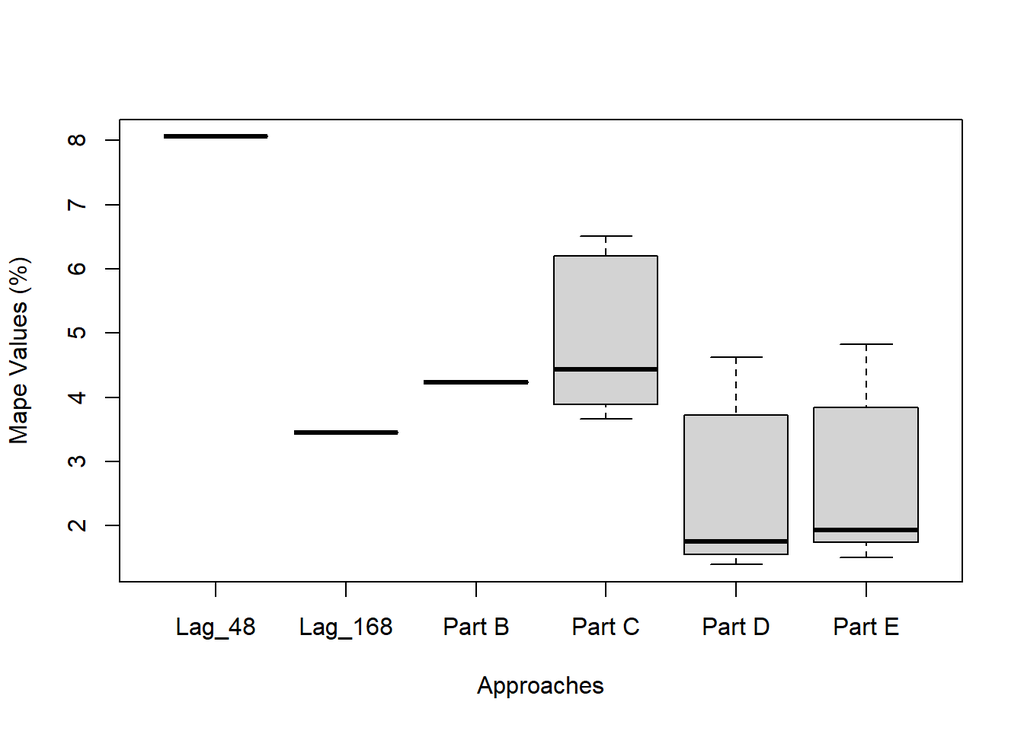

```r
boxplot(mape_lag48,mape_lag168,mapePartB,mapePartC, mapePartD ,mapePartE, names = c("Lag_48","Lag_168","Part B","Part C","Part D", "Part E"), xlab = "Approaches" , ylab = "Mape Values (%)")
```

If we really want to know whether our predictions are good or not, one way to do this is to compare them with the naive approaches. Those predictions with the naive approach can be seen as a baseline. Therefore, we see that the regression model we used in Part D (lasso regression) is the best and is very effective. The main reason for lasso regression having the best performance is because it uses penalized approach. fused approach has also performed well. Probably due to the chosen lambda value, it performed slightly bad compared to Part D. If the lambda value was chosen differently, we might observe an improvement and maybe with this way its performance would be better than Part D.

All in all, it is obvious that there are other regression models or approaches which are better than the naive approach. Thus, for predictions, regression algorithms, especially with penalties, must be used to make really good predictions. Also, parameters such as lambda must be chosen accordingly to get the highest performance.

Also, we can observe that the naive approach Lag_48 has the worst prediction performance. This was expected.